# HW6) Hurricanes and Maps

Stat 133, Fall 2023

Author

Casey Messersmith

**General Instructions**

- Write your code and content in a `qmd` (quarto markdown) file. You can use the template file `hw6-template.qmd` provided in bCourses.
- Name this file as `hw6-first-last.qmd`, where `first` and `last` are your first and last names (e.g. `hw6-gaston-sanchez.qmd`).
- Make sure the YAML header in your `qmd` files includes `embed-resources: true`
- Submit both your qmd and HTML files to the corresponding assignment submission in bCourses.
- Please note that submitting only one of the files will result in an automatic 15% deduction.
- Also, if you submit the incorrect files you will receive no credit.

# 2020 North Atlantic Hurricane Season

In this assignment, you are going to utilize the `storms` data set that comes in the tidyverse package `"dplyr"`. As you may know, `storms` contains data of tropical cyclones in the North Atlantic between 1975 and 2021 (assuming that you are using any of the recent `"dplyr"` versions, e.g. 1.1.0, 1.1.1, 1.1.2).

In particular, we are going to **focus on the 2020 season**, taking into account the information, claims, statistics, and details available in the associated Wikipedia entry (link below):

https://en.wikipedia.org/wiki/2020_Atlantic_hurricane_season

# 1 Prompts Specifically Involving 2020 Season

Each of the following parts is a statement extracted/derived from the above wikipedia entry. Use `"dplyr"` commands to obtain an output that confirms the given statement. If you find a discrepancy or a disagreement, provide a description and further commands/outputs that clarify what the issue is.

1. The 2020 Atlantic hurricane season featured a total of 31 depressions. BTW: Here the term *depression* refers to any kind of storm.

```r
#Pull out the data for 2020
desired_year = filter(storms, year == 2020)

#Pull out the necessary name column and count the number of distinct elements in this column
names = select(desired_year, name)

names |>
  group_by(name) |>
  summarise(n_distinct(name))
```

```
# A tibble: 30 × 2
   name      `n_distinct(name)`
   <chr>                  <int>
 1 Arthur                     1
 2 Bertha                     1
 3 Beta                       1
 4 Cristobal                  1
 5 Delta                      1
 6 Dolly                      1
 7 Edouard                    1
 8 Epsilon                    1
 9 Eta                        1
10 Fay                        1
# ℹ 20 more rows
```

```r
#Our table shows that for the storms in 2020, there are only 30 distinct storms, not 31. I can tell the total number of distinct storms for this year from the description "tibble: 30 x 2" which tells us that there are 30 unique rows, aka 30 unique storms. Although, the wiki article does say that only 30 of the storms are named so this could be the reason for this discrepancy.
```

2. In the 2020 Atlantic hurricane season, 14 storms developed into hurricanes.

```r
#Pull out the hurricane data for 2020
desired_year = filter(storms, year == 2020)
hurricanes = filter(desired_year, status == "hurricane")

#Count the number of hurricanes
hurricanes |>
  group_by(name) |>
    summarise(n_distinct(name))
```

```
# A tibble: 14 × 2
   name     `n_distinct(name)`
   <chr>                 <int>
 1 Delta                     1
 2 Epsilon                   1
 3 Eta                       1
 4 Gamma                     1
 5 Hanna                     1
 6 Iota                      1
 7 Isaias                    1
 8 Laura                     1
 9 Marco                     1
10 Nana                      1
11 Paulette                  1
12 Sally                     1
13 Teddy                     1
14 Zeta                      1
```

```r
#Our table shows that for the storms in 2020, there are a total of 14 distinct hurricanes that developed from storms. I know this is the number of distinct storms from the description "tibble: 14 x 2" which tells us that there are 14 unique rows, aka 14 unique hurricanes.
```

3. Of the hurricanes, seven intensified into major hurricanes.

```r
#Pull out the hurricane data for 2020
desired_year = filter(storms, year == 2020)
hurricanes = filter(desired_year, status == "hurricane")

#Pull out the major hurricanes and count the number of distinct ones
majors = filter(hurricanes, category >= 3)
majors |>
  group_by(name) |>
    summarise(n_distinct(name))
```

```
# A tibble: 7 × 2
  name    `n_distinct(name)`
  <chr>                <int>
1 Delta                    1
2 Epsilon                  1
3 Eta                      1
4 Iota                     1
5 Laura                    1
6 Teddy                    1
7 Zeta                     1
```

```r
#I looked this up online, but a "major" hurricane is category >= 3. According to our table, there were 7 major hurricanes in 2020. I know this is the number of distinct storms from the description "tibble: 7 x 2" which tells us that there are 7 unique rows, aka 7 unique major hurricanes.
```

4. Tropical storms Arthur and Bertha, formed early on May 16 and 27, respectively.

```r
#Pull out the data for Tropical Storm Arthur
desired_year = filter(storms, year == 2020)
Arthur = filter(desired_year, name == "Arthur")

#Determine the date of Arthur's start with the month and day columns
slice(select(Arthur, name, month, day), 1)
```

```
# A tibble: 1 × 3
  name   month   day
  <chr>  <dbl> <int>
1 Arthur     5    16
```

```r
#Since May is the 5th month of the year, the data shows that Tropical Storm Arthur began around May 16, as stated in the Wikipedia article.
```

```r
#Pull out the data for Tropical storm Bertha
desired_year = filter(storms, year == 2020)
Bertha = filter(desired_year, name == "Bertha")

#Determine the date of Bertha's start with the month and day columns
slice(select(Bertha, name, month, day), 1)
```

```
# A tibble: 1 × 3
  name   month   day
  <chr>  <dbl> <int>
1 Bertha     5    27
```

```r
#Since May is the 5th month of the year, the data shows that Tropical Storm Bertha began around May 27, as stated in the Wikipedia article.
```

# 2 Prompts Involving 2020 and Other Seasons

Like in the previous section, each of the following parts is a statement extracted/derived from Wikipedia. Use `"dplyr"` and `"ggplot2"` commands to obtain a **visualization** that confirms the given statement. Again, if you find a discrepancy or a disagreement, provide a description, further commands, and visual displays that clarify what the issue is.

**Tip**

Your graphics should be appropriate for sharing with outsiders. That means your graphs should have:

- title (possibly also a subtitle)
- labels on the axes
- good color contrast

This is just a starting point. Consider adopting your own color scales, taking control of your legends (if any), including annotations (if applicable), playing around with themes, etc.

## 2.1 Category 4 Hurricanes

According to Wikipedia: *“The 2020 season tied the record for most Category 4 hurricanes in a singular season in the Atlantic Basin.”*

```r
#Pull out the Category 4 hurricanes
cat4 = select(filter(storms, category == 4), year, category)


#Count the number of Category 4 hurricanes for each season
by_year <- group_by(cat4, year)
arrange(count(by_year), desc(n))
```

```
# A tibble: 36 × 2
# Groups:   year [36]
    year     n
   <dbl> <int>
 1  2004    49
 2  2005    37
 3  1999    35
 4  1995    33
 5  2003    31
 6  2010    30
 7  2021    29
 8  1989    26
 9  2017    25
10  1996    24
# ℹ 26 more rows
```

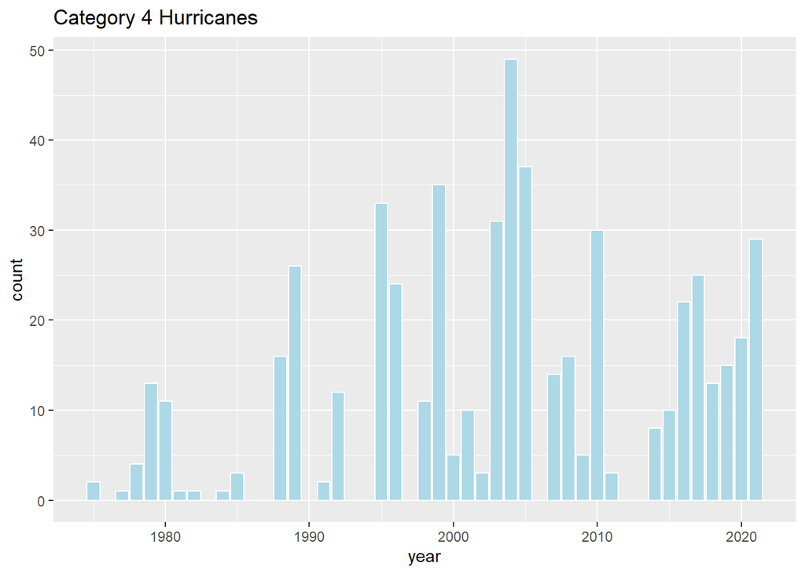

```r
#Not sure this is grouping correctly...!!
ggplot(cat4) +
  geom_bar(aes(year), color = "white", fill = "lightblue") + labs(title = "Category 4 Hurricanes")
```

## 2.2 Above Average Season

According to Wikipedia: *“The 2020 season was a well-above average activity season.”*

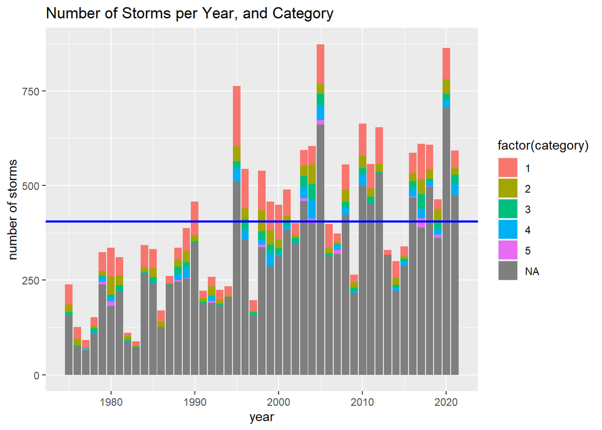

```r
#Pull out the storms per year and their categories
categories = select(storms, year, category)

#Count the number of storms per year
counts = categories |>  count(year)

#Calculate the average number of storms per year
#This will be used later to compare to 2020 in the graph!
vector_n = unlist(select(counts,n))
avg_num_storms_per_year = mean(vector_n)

#Plot the number of storms per year, and for fun separate it by the category of the storm
categories |>
  count(year, category) |>
  ggplot() + geom_col(aes(x = year, y = n, fill = factor(category))) +

  #Add a line horizontal line for the average number of storms per year, to visualize how 2020 compares to the average
  geom_hline(yintercept = avg_num_storms_per_year, color = "blue", linewidth = 1) +
  labs(title = "Number of Storms per Year, and Category", y = "number of storms")
```

```r
#As shown in the graph, the number of storms in 2020 well exceeds the average number of storms per year. The average number of storms per year is roughly 400, while for 2020 there appear to have been about 875 storms which is more than double the average!
```

# 3 Prompts Involving Making Maps

In each of the following parts you will have to produce at least one map that allows you to address or answer the provided statement. In addition, provide a description/explanation for each of your maps.

You can use any graph mapping approach. If you are not sure where/how to begin, we recommend that you take a look at chapter 18 from *R Tidy Hurricanes*:

https://www.gastonsanchez.com/R-tidy-hurricanes/maps-sf.html

Additionally, you can also review the slides discussed in class (week 7):

https://bcourses.berkeley.edu/courses/1526481/files/folder/slides?preview=87031155

https://bcourses.berkeley.edu/courses/1526481/files/folder/slides?preview=87077071

**Important Hints and Tips**

Your maps should be appropriate for sharing with outsiders. That means your maps should have:

- title (possibly also a subtitle)
- good color contrast
- annotations, legends, labels, when applicable/appropriate

This is just a starting point. Consider adopting your own color scales, taking control of your legends (if any), including annotations (if applicable), playing around with themes, etc.

## 3.1 Map of Hurricane Seasons by Month

As you know, the *official* hurricane season in every year goes from June-1 to November-30. It is said that September, historically speaking, is the most active month, followed by August in second place, and October in third place.

Make a graphic to visualize maps, **faceting by month**, of *ALL* storms in the North Atlantic during the hurricane season months of all years from 1975 to 2021. Does your plot support the claim about the top-3 most active months?

**Important**

**Hint**: We recommend plotting the trajectories of storms with `geom_path()` instead of `geom_point()`. An effective use of `geom_path()` requires an aesthetic `group` argument. We suggest creating a new ID column that combines the `name` and `year` of storms; this ID column can be used for the `group` argument. How do you add an ID column? Here’s an example: filtering storms in the 1970s, we could add an `id` column as follows:

```r
# hint: adding an "id" column for ggplot convenience so that you
# can use it on an aesthetic 'group' argument
storms70 = storms |>
  filter(year %in% 1975:1979) |>
  mutate(id = paste0(name, "-", year))
```

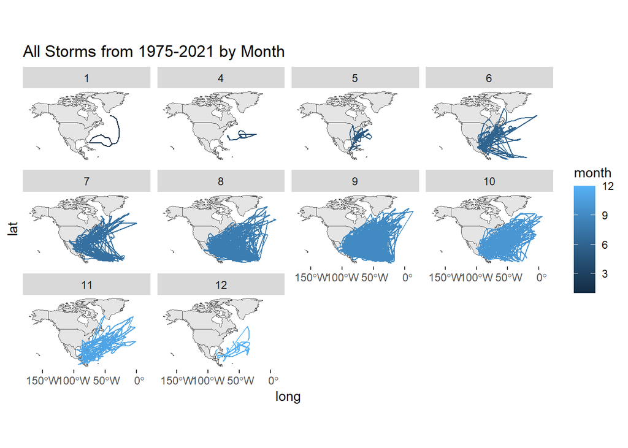

```r
#Add an ID column for ggplot convenience
all_storms = storms |>
  mutate(id = paste0(name, "-", year))

#Generate map template
map_north_america = ne_countries(continent = "north america",
                                 returnclass = "sf")

#Plot map and desired storm data
ggplot()+
  geom_sf(data = map_north_america) +
  geom_path(data = all_storms, aes(x = long, y = lat, group = month, color = month)) +
  theme(panel.background = element_blank()) + facet_wrap(~ month) + labs(title = "All Storms from 1975-2021 by Month")
```

```r
#As shown in the graphs, the most active months of the year on average seem to be months 9, 8, and 10 in that order. These numbers correspond to September, August, and October respectively, which matches the information given in the Wikipedia article.
```

## 3.2 Map of Hurricane Laura (2020)

According to Wikipedia: “Laura made landfall in Louisiana as a Category 4 hurricane.” Graph a map of Laura’s trajectory that lets you see its path, where it made landfall in the US, and under what category class it made landfall.

**Important Hints and Tips**

Recall that the category of a storm is determined by the Saffir-Simpson wind scale: https://en.wikipedia.org/wiki/Saffir%E2%80%93Simpson_scale

Also, keep in mind that column `wind` is measured in knots.

Likewise, if you use `"rnaturalearth"`, the function `ne_states()`—see command below—lets you obtain a map of US states that can be added to your continental map with another `geom_sf()` layer.

```r
ne_states(country = "United States of America", returnclass = "sf")
```

Review the steps listed in the HTML of instructions (see **Sample Tutorial 1**). They give you a guideline to `mutate()` the values in column `category`, because of ggplot convenience.

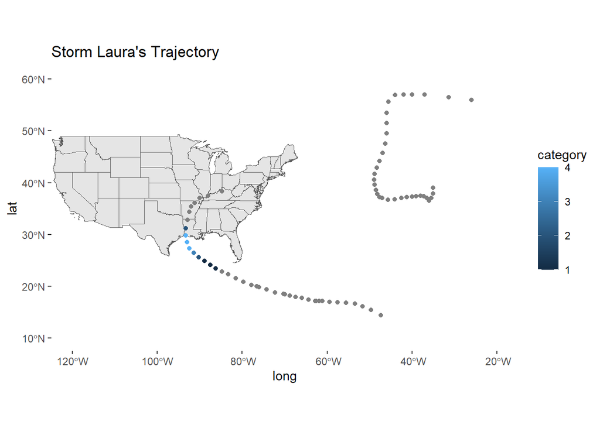

```r
#Edit storms data for ggplot convenience
storms_edited = storms |>
  mutate(category = factor(case_when(
    is.na(category) ~ 0,
    category == 1 ~ 1,
    category == 2 ~ 2,
    category == 3 ~ 3,
    category == 4 ~ 4,
    category == 5 ~ 5,
  )))

#Generate map template
#map_north_america = ne_countries(continent = "north america",
#                                 returnclass = "sf")
map_states = ne_states(country = "United States of America", returnclass = "sf")

#Pull out the data for Storm Laura
Laura = filter(storms, name == "Laura")

#Plot map and data for Storm Laura
map_Laura_trajectory = ggplot()+
  geom_sf(data = map_states) +
  geom_point(data = Laura, aes(x = long, y = lat, color = category)) + coord_sf(xlim = c(-120, -20), ylim = c(10,60)) + theme(panel.background = element_blank()) + labs(title = "Storm Laura's Trajectory")
map_Laura_trajectory
```

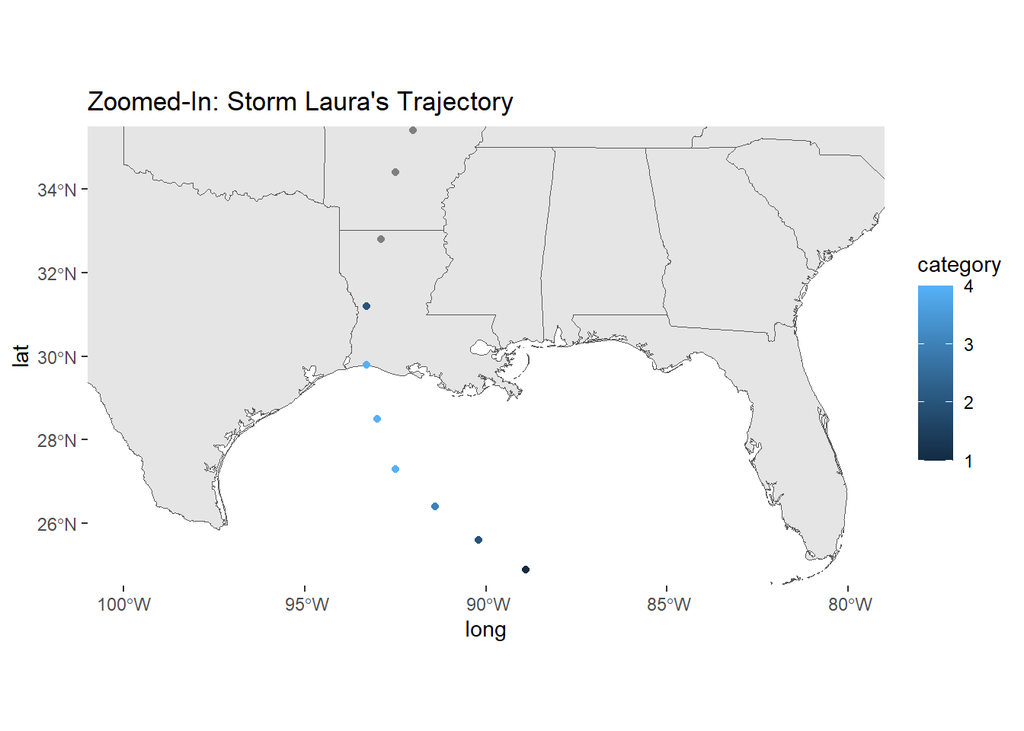

```r
#Zomed in!
zoomed_map = ggplot()+
  geom_sf(data = map_states) +
  geom_point(data = Laura, aes(x = long, y = lat, color = category)) + coord_sf(xlim = c(-100, -80), ylim = c(25,35)) + theme(panel.background = element_blank()) + labs(title = "Zoomed-In: Storm Laura's Trajectory")
zoomed_map
```

```r
#As shown in the graph, Storm Laura made landfall in the US in Louisiana and it made this landfall as a category 4 hurricane. This observation from our map fits with the information from the Wikipedia article.
```

## 3.3 Category 5 Hurricanes in October

Make a map showing the trajectories, and their name-year of all category 5 hurricanes that have occurred (been active) in the month of October (among all years 1975 - 2021). To clarify: this map should contain the full trajectory of every category-5 hurricane that has occurred between years 1975 and 2021 during the month of October.

**Important Hints and Tips**

Review the steps listed in the HTML of instructions (see **Sample Tutorial 2**). They give you a guideline to get the appropriate data for the requested map.

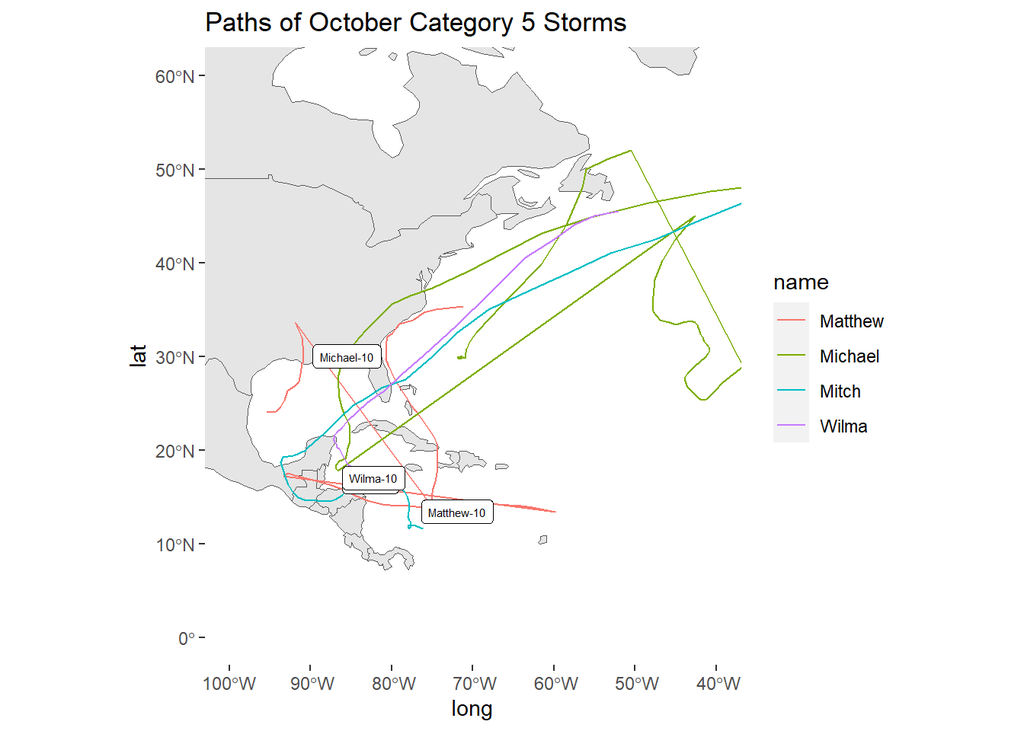

```r
#Create a table for the category 5 storms across all years
#Define category 5 as winds >= 137 since the wind column in measured in knots.
cat5_ids = storms |>
  mutate(id = paste0(name, "-", month)) |>
  group_by(id) |>
  summarise(
    month = month,
    wind_max = max(wind),
    .groups = "drop") |>
  filter(wind_max >= 137)
#Remove duplicate rows
unique_cat5_ids = cat5_ids |> distinct()

#Create a table that identifies all category 5 hurricanes in October
oct_cat5_ids = filter(unique_cat5_ids, month == 10)

#Now add the id column to the category 5 storms
cat5_storms = storms |>
  filter(wind >= 137) |>
  select(name, year, month, long, lat, wind) |>
  mutate(id = paste0(name, "-", month)) |>
  group_by(id)

#Now grab the data for October, Category 5 Storms
oct_cat5_storms = semi_join(cat5_storms, oct_cat5_ids)
#Grab the entire storm path for a nicer map!
full_paths = storms |> filter(name == "Mitch" | name == "Wilma" | name == "Matthew" | name == "Michael")

#Set up table for Label Names
ids_oct_cat5 = oct_cat5_storms |>
  select(id, long, lat) |>
  group_by(id) |>
  summarise(lat = first(lat), long = first(long))

#Plot each storm path
map_north_america = ne_countries(continent = "north america",
                                 returnclass = "sf")

map_paths = ggplot() + geom_sf(data = map_north_america) +
  geom_path(data = full_paths, aes(x = long, y = lat, group = name, color = name)) +
  coord_sf(xlim = c(-100, -40), ylim = c(0,60)) +
  theme(panel.background = element_blank()) + labs(title = "Paths of October Category 5 Storms") +
  geom_label(ids_oct_cat5, mapping = aes(x = long, y = lat, label = id), size = 2)

map_paths
```

```r
#Unfortunately I could not figure out how to move the "Wilma" Label to show the "Mitch" Label!
```

## Rubric

- 😞 **None (0 pts)**: No submission; or terribly wrong; or incorrect files.
- 😟 **Deficient (1 pt)**: Displays minimal effort. Fairly incomplete. Code is poorly written and not documented.
- 🙁 **Needs improvement (2 pts)**: Displays some effort. Doesn’t complete all components. Code is poorly written and not documented. Just contains code and output but no descriptions, explanations or interpretations. Or vice versa, just contains output and descriptions but no code. Possibly a major issue or critical mistake. Does not take care of well presented content (e.g. improper use of markdown elements, messy content, hard to follow).
- 😐 **Satisfactory (3 pts)**: Decent effort. Hits all the elements. Possibly a couple of minor mistakes or some non-minor issue. Fairly easy to follow (both the code and the output). Most plots are produced with default settings (minimal or no customization). Overly simplistic explanations and interpretations. Nothing spectacular, either bad or good.
- 🙂 **Good (4 pts)**: Solid effort. Hits all the elements. Possibly a minor mistake. Easy to follow (both the code and the output). Most plots are customized (labels, colors, theme, etc). Takes care of well presented information (e.g. proper use of markdown elements, no spelling issues, well organized).
- 😀 **Excellent (5 pts)**: Code written succinctly, comprehensibly, and properly formatted. Easy to follow (both the code and the output). Content is extremely well organized. Graphs properly labeled/annotated. Uses non-default settings, highly customizing the graphics to give them an outstanding appearance (i.e. publication quality). Descriptions are clear and easy to follow, either because graphs are labeled clearly or you’ve written additional text to describe how you interpret the output. Spectacular submission, that can be used as an *exemplary solution*.